# 2. Nizovi podataka i linijski dijagrami

U ovoj lekciji ćete naučiti:

1. kako se kretati kroz radnu bilježnicu Jupytera;
2. kako se pišu nizovi podataka; i
3. kako su nizovi podataka prikazani linijskim dijagramima.

## 2.1. Još malo o Jupyter radnoj bilježnici

Radna bilježnica za Jupyter sastoji se od niza ćelija, a svaka ćelija može sadržavati tekst, matematički izraz ili niz Python naredbi. Niz ikona na vrhu stranice omogućuje vam manipuliranje Jupyterovim radnim knjigama na različite načine:

[figure not shown]

- Klikom na gumb nalik na disketu (prvi lijevo) snimit ćete radnu bilježnicu.
- Klikom na znak **+** dodat ćete novu ćeliju ispod aktivne ćelije. (Ćeliju aktivirate klikom na nju; aktivna ćelija ima okvir ***green*** ili ***blue***.
- Strelice gore i dolje radnu ćeliju pomiču za jedno mjesto prema gore ili prema dolje.

Na primjer, čitate ovaj tekst i odjednom osjetite snažnu želju za izračunom vrijednosti izraza $1 + \frac 12 + \frac 13 + \frac 14 + \frac 15 + \frac 16 + \frac 17$. Zatim trebate kliknuti na ovu ćeliju (koju upravo čitate), a zatim na gumb **+**. U novu ćeliju koja se pojavi ispod možete unijeti izraz i Python će ga izračunati:

```python
1 + 1/2 + 1/3 + 1/4 + 1/5 + 1/6 + 1/7
```

```
2.5928571428571425
```

Osam ćelija koje slijede stihovi su poznatog engleskog dječjeg brojača. Stihovi su isprepleteni. Upotrijebite tipke sa strelicama da preuredite ćelije tako da dobijete tekst brojača.

*Once I caught a fish alive,*

*Then I let it go again.*

*Which finger did it bite?*

*Why did you let it go?*

*Because it bit my finger so.*

*This little finger on my right.*

*One, two, three, four, five,*

*Six, seven, eight, nine, ten,*

## 2.2. Zapisivanje niza podataka

Nizovi podataka Pythona pišu se unutar uglatih zagrada u obliku liste. Na primjer, ocjene učenika iz jednog predmeta mogu se napisati kao niz ovako:

```python
ocjene = [2, 4, 5, 3, 5]
```

Sustav, naravno, nije vratio nikakav izlaz. Primijetio je samo da varijabla `ocjene` sada sadrži niz koji se sastoji od pet brojeva. Da bismo se uvjerili da je to slučaj, tražit ćemo od sustava da izračuna slijedeći izraz:

```python
ocjene
```

```
[2, 4, 5, 3, 5]
```

Moguće je raditi i s nizovima stringova:

```python
predmeti = ["Matematika", "Engleski", "Likovni", "Povijest", "Tjelesni"]
```

Sustav ovaj put nije vratio nijedan izlaz, samo je zapamtio da varijabla `predmeti`, sada sadrži niz od pet stringova (imena predmeta). Evo sadržaja varijable `predmeti`:

```python
predmeti
```

```
['Matematika', 'Engleski', 'Likovni', 'Povijest', 'Tjelesni']
```

Dužinu niza možemo dobiti pozivom funkcije `len` (što je skraćenica engleske riječi length koja znači “dužina”):

```python
len(predmeti)
```

```
5
```

## 2.3. Prikazivanje niza podataka

Sljedeća ćelija prikazuje procijenjenu populaciju našeg planeta u različitim povijesnim razdobljima, sa brojem ljudi izraženim u milijardama:

```python
godine       = [1000,  1500, 1650, 1750, 1804, 1850, 1900, 1930, 1950, 1960, 1974, 1980, 1987, 1999, 2011, 2020, 2023, 2030, 2037, 2045, 2055, 2100]
ljudi  = [0.275, 0.45, 0.5,  0.7,  1,    1.2,  1.6,  2,    2.55, 3,    4,    4.5,  5,    6,    7,    7.8,  8,    8.5,  9,    9.5,  10,   11.2]
```

Željeli bismo prikazati ove podatke u obliku grafikona (`prikazati ih`) jer su ljudi najlakši i najbrži način obrade vizualnih podataka. (Vjerojatno znate izreku da `jedna slika vrijedi više od tisuću riječi`.)

Python ima razne biblioteke za vizualizaciju podataka, a mi ćemo koristiti knjižnicu koja se zove `matplotlib.pyplot`. Kako je ovaj naziv vrlo dugačak i kompliciran i budući da će nam trebati brojne funkcije iz te biblioteke, nećemo uvoziti funkcije jednu po jednu, već ćemo uvesti cijelu biblioteku dok joj dajemo kraći naziv (tako reći) `plt`. (Engleska riječ plot znači "plot", a plt je kratica za plot.)

```python
import matplotlib.pyplot as plt
```

Sada su nam dostupne sve značajke u ovoj biblioteci. Važno je napomenuti da se *jedan* `import` *odnosi na čitavu radnu knjižicu!* Dakle, dovoljno je jednom uvesti biblioteku u radnu knjižicu. Važno je također reći da ćemo u novoj radnoj knjižici morati ponovno uvesti biblioteku koje nam trebaju za rad.

**Jedan import po radnoj knjižici!**

Ako zabrljate i pokušate uvesti knjižnicu dva puta - bez brige. Python se neće pobuniti, ali neće gubiti vrijeme dvaput učitati istu biblioteku.

Natrag na crtež grafikona. Najjednostavniji grafikon može se dobiti kako slijedi:

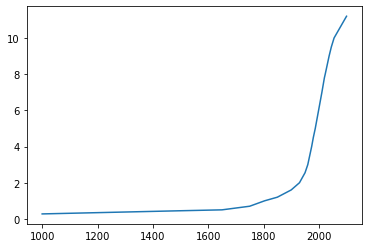

```python
plt.plot(godine, ljudi)
plt.show()
plt.close()
```

Funkcija `plot(years, population)` nalaže sustavu da crta graf koji prikazuje podatke iz niza `godine` na vodoravnoj osi ($x$-osi), i okomitoj osi ($y$-osi) podaci iz niza `ljudi`. Funkcija `show` tada prikazuje grafikon. (Engleska riječ plot znači „privući“, a engleska riječ *show* znači „pokazati“.) Napokon, funkcija `close` završava rad na grafikonu (engleska riječ *close* znači „zatvoriti“).

Vidimo da su podaci predstavljeni linijom. Zato se ova vrsta grafikona naziva *linijski grafikon*.

Budući da nismo uvezli pojedinačne funkcije, već smo uveli čitavu biblioteku pod nadimkom `plt` funkcije `plot`, `show` i `close` moramo povati "punim imenom i prezimenom": `plt.plot`, `plt.show` i `plt.close`.

U narednom koraku ćemo grafikonu dodati naslov koristeći funkciju `title` (engleska reč *title* znači "naslov"):

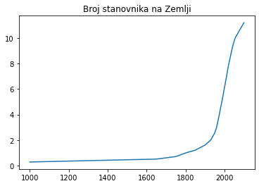

```python
plt.plot(godine, ljudi)
plt.title("Broj stanovnika na Zemlji")
plt.show()
plt.close()
```

Na okomitu os možemo staviti i oznaku da naglasimo da su brojke u milijardama. Da bismo to učinili, koristimo funkciju `ylabel` ("oznaka na $y$-osi"; engleska riječ *label* znači "oznaka"):

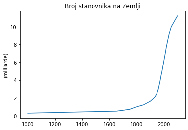

```python
plt.plot(godine, ljudi)
plt.title("Broj stanovnika na Zemlji")
plt.ylabel("(milijarde)")
plt.show()
plt.close()
```

Za zaključak: grafikon funkcija `plot`, `title` i `ylabel` u grafikon dodajemo podatke, a tek kada na grafikon unesemo sve podatke koje želimo imati, crtamo grafikon pozivajući funkciju `show`. Napokon, pozivamo funkciju `close` da počisti nakon nas.

## 2.4. Zadaci

**Zadatak 1.** Sljedeći program crta grafikon koji predstavlja procijenjeni broj ljudi na Zemlji u raznim periodima:

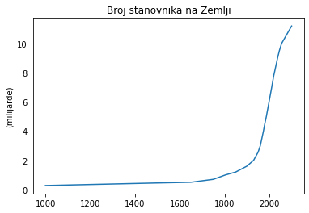

```python
import matplotlib.pyplot as plt
plt.plot(godine, ljudi)
plt.title("Broj stanovnika na Zemlji")
plt.ylabel("(milijarde)")
plt.show()
plt.close()
```

1. Čemu služi naredba `import ... as ..`?
2. Zašto pišemo `plt.plot`, a ne `plot`?
3. Čemu služi funkcija `plot`?
4. Čemu služi funkcije `title` i `ylabel`?
5. Čemu služi funkcije `show` i `close`?

Sljedeće primjere riješite u Jupyteru.

**Zadatak 2.** Sljedeća ćelija daje podatke o težini (u kilogramima) i dužini/visini (u centimetrima) jednog dječaka u dobi od šest mjeseci do dobi od 6,5 godina.

```python
mjerenja    = ["6 mje", "1.5 god", "2.5 god", "3.5 god", "4.5 god", "5.5 god", "6.5 god"]
težinaKG  = [5.9,   11.5,    14.8,    20.5,    22.0,    24.2,    29.0   ]
visinaCM  = [62.0,  84.0,    97.0,    115.0,   122.5,   131.5,   135.0  ]
```

Pokažite s jednim grafikonom kako se mijenjala njegova težina, a drugim kako se mijenjala njegova visina.

**Zadatak 3.** *Indeks tjelesne mase*, BMI, je kvocijent tjelesne mase izražen u kilogramima i kvadratnom visinom tijela u metrima:

$$\hbox{BMI} = \frac{\hbox{težina u kilogramima}}{(\hbox{visina u metrima})^2}$$

Za dječaka iz zadatka 2 na grafikonu pokažite promjenu u njegovom indeksu tijelesne težine. Sljedeći mali program Python koji izračunava svoje indekse tjelesne težine za svako mjerenje može vam pomoći:

```python
BMI = [0, 0, 0, 0, 0, 0, 0]
for i in range(0, 7):
    BMI[i] = težinaKG[i] / (visinaCM[i] / 100.0)**2
```

**Zadatak 4.** Kina se procjenjuje na 1.7.2019. imala je 1.420.062.022 stanovnika. Kinesko stanovništvo se svake godine povećava za 0,35%. Pod pretpostavkom da se godišnji rast stanovništva u Kini neće promijeniti, grafikon očekivanog broja stanovnika Kine u sljedećih deset godina.

© 2019 [Petlja.org](https://petlja.org)